# Stats 20, F23 – Homework 7

Daren Sathasivam – 306229580

12/11/23

## Question 1

### (a)

```r
births <- read.csv("births.csv", stringsAsFactors = TRUE)
str(births)
```

```
## 'data.frame':    1998 obs. of  21 variables:
##  $ Gender      : Factor w/ 2 levels "Female","Male": 2 1 2 1 2 1 2 2 1 1 ...
##  $ Premie      : Factor w/ 2 levels "No","Yes": 1 1 1 1 1 1 1 1 1 1 ...
##  $ weight      : int  124 177 107 144 117 98 147 138 104 123 ...
##  $ Apgar1      : int  8 8 3 6 9 4 8 9 9 9 ...
##  $ Fage        : int  31 36 30 33 36 31 33 22 30 23 ...
##  $ Mage        : int  25 26 16 37 33 29 30 20 21 18 ...
##  $ Feduc       : int  13 9 12 12 10 14 12 14 12 12 ...
##  $ Meduc       : int  14 12 8 14 16 16 9 14 12 12 ...
##  $ TotPreg     : int  1 2 2 2 2 3 4 1 1 1 ...
##  $ Visits      : int  13 11 10 12 19 20 16 10 30 16 ...
##  $ Marital     : Factor w/ 2 levels "Married","Unmarried": 1 2 2 2 1 1 1 2 2 2 ...
##  $ Racemom     : Factor w/ 4 levels "Asian","Black",..: 4 4 4 4 4 4 4 2 2 4 ...
##  $ Racedad     : Factor w/ 5 levels "Asian","Black",..: 5 5 4 5 2 5 5 2 4 5 ...
##  $ Hispmom     : Factor w/ 3 levels "Mexican","NotHisp",..: 2 1 1 2 2 2 1 2 2 1 ...
##  $ Hispdad     : Factor w/ 4 levels "Mexican","NotHisp",..: 2 1 4 2 2 2 1 2 4 1 ...
##  $ Gained      : int  40 20 70 50 40 21 22 20 11 19 ...
##  $ Habit       : Factor w/ 3 levels "","NonSmoker",..: 2 2 2 2 2 2 2 2 2 2 ...
##  $ MomPriorCond: Factor w/ 2 levels "At Least One",..: 2 2 1 2 1 2 2 2 1 2 ...
##  $ BirthDef    : Factor w/ 2 levels "At Least One",..: 2 2 2 2 2 2 2 2 2 2 ...
##  $ DelivComp   : Factor w/ 2 levels "At Least One",..: 1 1 1 1 2 2 1 1 2 1 ...
##  $ BirthComp   : Factor w/ 2 levels "At Least One",..: 2 2 2 2 2 2 2 2 2 2 ...
```

### (b)

```r
levels(births$Habit)
```

```
## [1] ""          "NonSmoker" "Smoker"
```

```r
births[births$Habit == "", ]
```

```
##      Gender Premie weight Apgar1 Fage Mage Feduc Meduc TotPreg Visits   Marital
## 41     Male     No    135      9   35   28    17    16       3     14   Married
## 577  Female     No     92      8   30   42    12    14      11     12 Unmarried
## 684  Female     No    131      9   24   21    12    12       3     13   Married
## 984  Female     No    132      8   47   43    16    17       2     28   Married
## 1292 Female     No     91      9   30   28    12     6       7     17 Unmarried
## 1501   Male     No    131      8   33   33    17    16       5     12   Married
##      Racemom Racedad   Hispmom Hispdad Gained Habit MomPriorCond BirthDef
## 41     White   White   NotHisp NotHisp     30               None     None
## 577    Black Unknown   NotHisp Unknown      0       At Least One     None
## 684    White   Other   NotHisp NotHisp     30       At Least One     None
## 984    White   White   NotHisp NotHisp     30               None     None
## 1292   White Unknown OtherHisp Unknown     30               None     None
## 1501   White   White   Mexican NotHisp     30               None     None
##         DelivComp BirthComp
## 41   At Least One      None
## 577  At Least One      None
## 684          None      None
## 984          None      None
## 1292 At Least One      None
## 1501 At Least One      None
```

```r
sum(births$Habit == "")
```

```
## [1] 6
```

```r
length(which(births$Habit == ""))
```

```
## [1] 6
```

There are 6 observations with no information on the Habit of a mother. The name of the category for these observations is an empty string ““.

### (c)

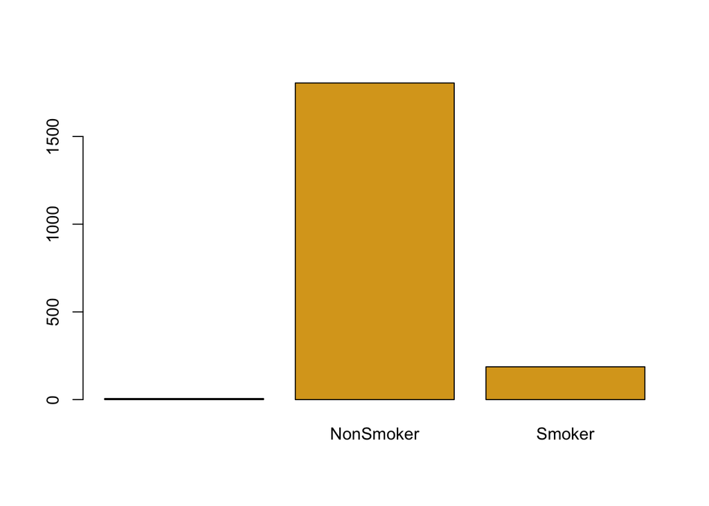

```r
barplot(table(births$Habit), col = "goldenrod")
```

### (d)

```r
subset_births <- births[births$Habit %in% c("Smoker", "NonSmoker"), ]
subset_births$Habit <- droplevels(subset_births$Habit)
write.csv(subset_births, "subset_births.csv")
```

### (e)

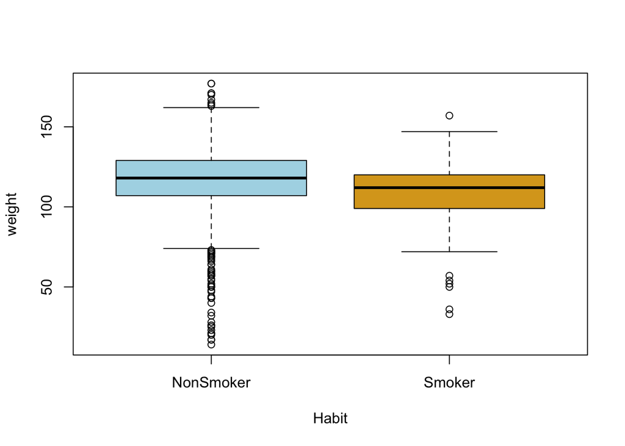

```r
boxplot(weight ~ Habit, data = subset_births, col = c("lightblue", "goldenrod"))
```

## Question 2

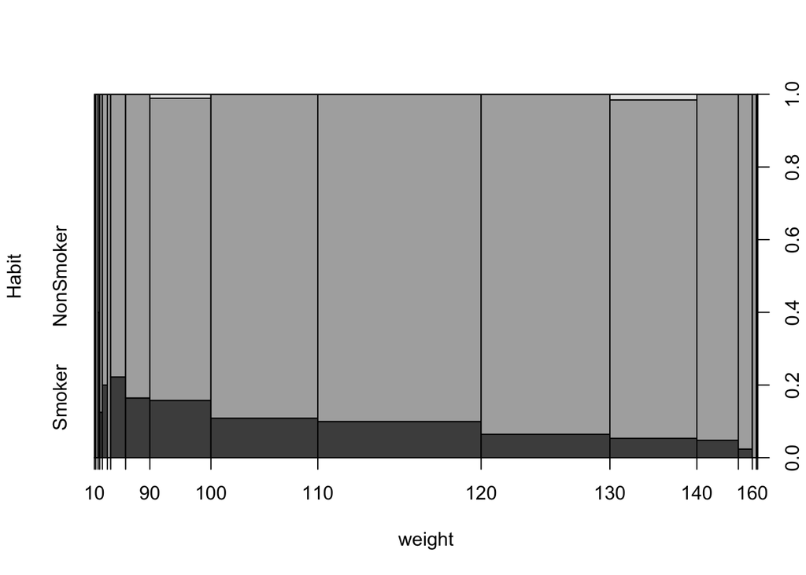

```r
plot(Habit ~ weight, data = births)
```

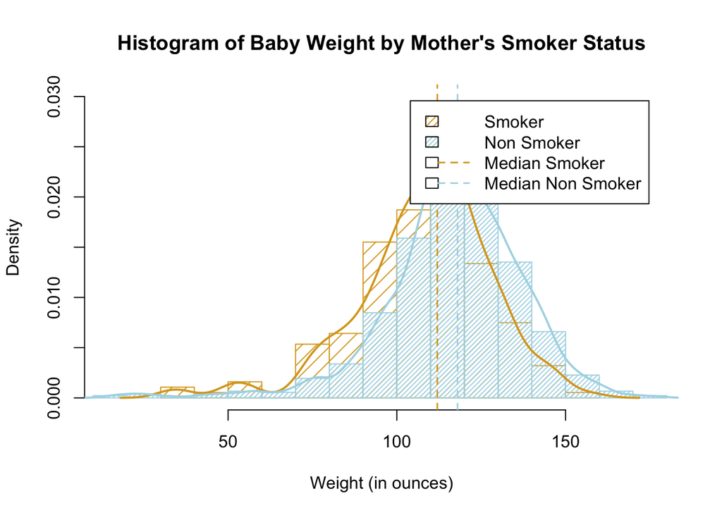

```r
smokers <- births[births$Habit == "Smoker", ]
non_smokers <- births[births$Habit == "NonSmoker", ]
with(births, hist(weight[Habit == "Smoker"],
  prob = TRUE, density = 10, col = "goldenrod",
  main = "Histogram of Baby Weight by Mother's Smoker Status",
  xlab = "Weight (in ounces)",
  xlim = range(births$weight), ylim = c(0, 0.030)
))
with(births, hist(weight[Habit == "NonSmoker"],
  prob = TRUE, density = 30, col = "lightblue",
  breaks = 20, add = TRUE
))
lines(density(smokers$weight), lwd = 2, col = "goldenrod")
lines(density(non_smokers$weight), lwd = 2, col = "lightblue")
abline(v = median(smokers$weight), col = "goldenrod", lwd = 1.5, lty = 2)
abline(v = median(non_smokers$weight), col = "lightblue", lwd = 1.5, lty = 2)
legend("topright", c("Smoker", "Non Smoker", "Median Smoker", "Median Non Smoker"),
  density = c(20, 30, NA, NA),
  fill = c("goldenrod", "lightblue", "white", "white"),
  lty = c(1, 1, 2, 2),
  lwd = c(NA, NA, 1.5, 1.5),
  col = c(NA, NA, "goldenrod", "lightblue"),
  inset = 0.05
)
```

## Question 3

### (a)

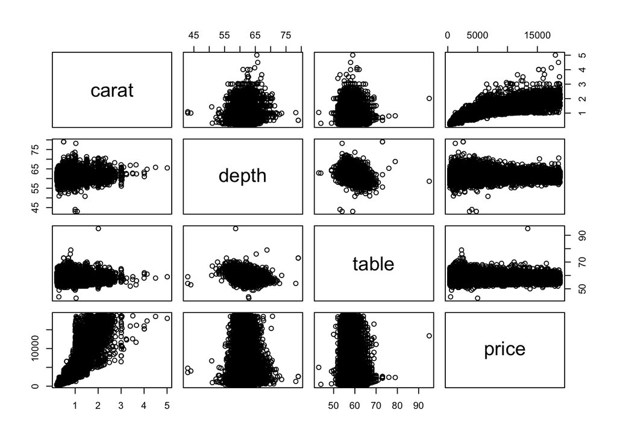

```r
library(ggplot2)
data(diamonds)
# head(diamonds)
pairs(diamonds[, c("carat", "depth", "table", "price")])
```

### (b)

```r
plot(price ~ carat, data = diamonds, col = diamonds$clarity, pch = 15, cex = 0.3)
levels(diamonds$clarity)
```

```
## [1] "I1"   "SI2"  "SI1"  "VS2"  "VS1"  "VVS2" "VVS1" "IF"
```

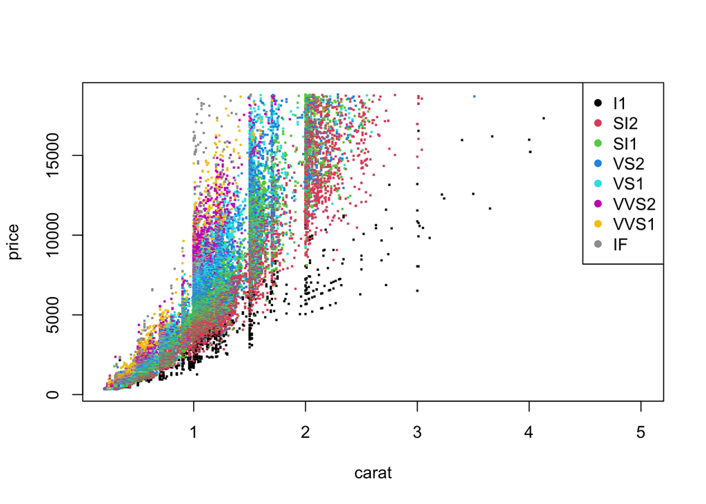

```r
legend("topright", legend = levels(diamonds$clarity), col = 1:8, pch = 16, cex = 1)
```

The default colors of 1 to 8 are chosen because the number of levels the clarity object contains is 8. Each level receives a different color, hence the 8 different colors.

### (c)

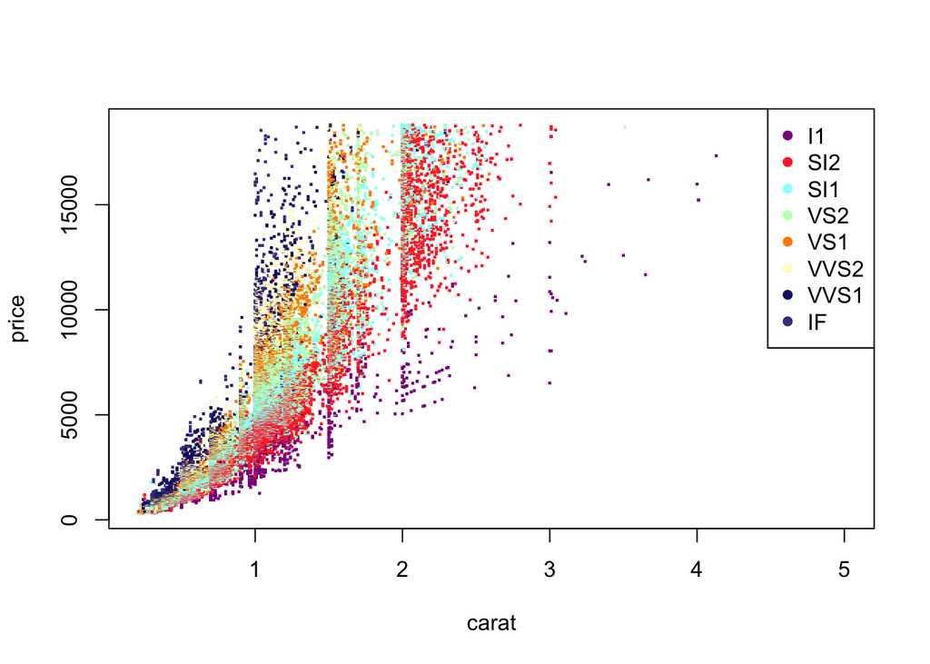

```r
new_colors <- c("darkmagenta", "firebrick1", "darkslategray1", "darkseagreen1", "darkorange", "lemonchiffon", "midnightblue", "slateblue4")
plot(price ~ carat, data = diamonds, col = new_colors[diamonds$clarity], pch = 15, cex = 0.3)
legend("topright", legend = levels(diamonds$clarity), col = new_colors, pch = 16, cex = 1)
```

### (d)

The three way relationship tells viewers that there is correlation between a diamond’s price and the carat. Additionally, a user can observe patterns in the clarity in correlation to both price and the carat of a diamond. For example, it can be observed that the l1 diamonds tend to be cheaper in comparison to Sl2 diamonds.

## Question 4

### (a)

```r
# levels(diamonds$cut)
# levels(diamonds$color)
as.matrix(tapply(diamonds$price, list(diamonds$color, diamonds$cut), mean))
```

```
##       Fair     Good Very Good  Premium    Ideal
## D 4291.061 3405.382  3470.467 3631.293 2629.095
## E 3682.312 3423.644  3214.652 3538.914 2597.550
## F 3827.003 3495.750  3778.820 4324.890 3374.939
## G 4239.255 4123.482  3872.754 4500.742 3720.706
## H 5135.683 4276.255  4535.390 5216.707 3889.335
## I 4685.446 5078.533  5255.880 5946.181 4451.970
## J 4975.655 4574.173  5103.513 6294.592 4918.186
```

### (b)

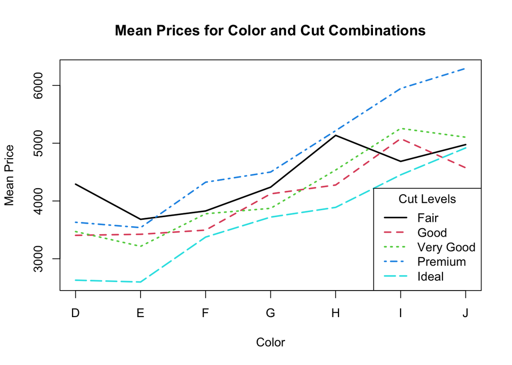

```r
mean_matrix <- as.matrix(tapply(diamonds$price, list(diamonds$color, diamonds$cut), mean))

matplot(mean_matrix, type = "l", lty = 1:5, lwd = 2, col = seq_len(ncol(mean_matrix)), xaxt = "n", xlab = "Color", ylab = "Mean Price", main = "Mean Prices for Color and Cut Combinations")

legend("bottomright", legend = levels(diamonds$cut), col = seq_len(ncol(mean_matrix)), lty = 1:5, lwd = 2, title = "Cut Levels", cex = 1)

axis(1, at = seq_len(nrow(mean_matrix)), labels = levels(diamonds$color))
```